# LBP Analysis - Fiber Study

Brian

2023-05-17

## Objective

To determine whether LBP concentration is altered from fiber supplementation in healthy participants and to explore if LPB concentration is correlated with subject characteristics, microbes, and metabolites.

## Statistical Analysis

The statistical analyses for this study were conducted using R software (version 4.2.2), a programming language and free software environment for statistical computing and graphics supported by the R Foundation for Statistical Computing.

For the analysis of repeated measures data, a linear mixed model approach was employed. This method is particularly suitable for repeated measures data as it accounts for the within-subject correlation that arises from repeated measurements on the same subject over time. To implement this model, the lmerTest package in R was used, which provides p-values in type III analysis of variance tables with Satterthwaite’s or Kenward-Roger’s methods for denominator degrees-of-freedom approximation.

Post-hoc tests on the linear mixed models were performed using the emmeans package. This package provided estimated marginal means (EMMs, previously known as least-squares means in the context of traditional regression models) for many linear, generalized linear, and mixed models.

To assess the relationships between variables, a correlation analysis was performed. Because our data involved repeated observations on the same subjects, a standard correlation analysis was not appropriate as it would not account for the non-independence of the observations. Instead, a repeated measures correlation analysis was performed using the rmcorr package in R. This method provides a measure of the common association among repeated measures for two variables, which is particularly useful when the measures are collected on the same metric and over the same timeframe.

All statistical tests were two-tailed, and a p-value of less than 0.05 was considered statistically significant. This threshold was chosen to control the Type I error rate and to balance between the risk of false positives and the risk of false negatives.

## Shortened statistical analysis method for manuscript

All analyses were performed using R version 4.2.2. A linear mixed model was implemented with the lmerTest package to account for repeated measures. Post-hoc tests on these models utilized the emmeans package. Correlations between variables, considering the repeated measures nature of the data, were analyzed using the rmcorr package. Statistical significance was set at a p-value of less than 0.05.

## Packages

```r
if(!any(rownames(installed.packages()) == "pacman"))
        install.packages("pacman")

pacman::p_load(here,
               tidyverse,
               rstatix,
               DT,
               ggpubr,
               multcomp,
               readxl,
               reshape2,
                forcats,
               drc,
               emmeans,
               lmerTest,
               rmcorr)
```

## Data Cleaning

```r
standard <- read_excel(here("LBP","standard","standard_lbp.xlsx"))
subject_characteristic <- read_csv(here("subject_characteristics","USANA Study Clinical Meta Data Sheet copy.csv")) |>
    mutate(sample = as.character(sample)) |>
    na.omit()
plate_1 <- read_excel(here("LBP","raw","fslbp1-40.xlsx"),
                    sheet = "Sheet1",
                    range = "B46:N54",

) |>
        column_to_rownames(var = 1) |>
        as.matrix() |>
        melt(value.name = "absorbance",
             na.rm = TRUE)
plate_1$position <- paste0(plate_1$Var1, plate_1$Var2)


plate_2 <- read_excel(here("LBP","raw","fslbp41-80.xlsx"),
                    sheet = "Sheet1",
                    range = "B77:N85",

) |>
        column_to_rownames(var = 1) |>
        as.matrix() |>
        melt(value.name = "absorbance",
             na.rm = TRUE)
plate_2$position <- paste0(plate_2$Var1, plate_2$Var2)

plate_layout_1 <-  read_excel(here("LBP","plate_design","fslbp1-40_plate_design.xlsx"),
                    range = "A1:M9",
                    sheet = "Sheet1"

) |>
        column_to_rownames(var = 1) |>
        as.matrix() |>
        melt() |>
        rename(sample = "value") |>
        filter(!sample %in% "NA")
plate_layout_1$position <- paste0(plate_layout_1$Var1, plate_layout_1$Var2)


plate_layout_2 <-  read_excel(here("LBP","plate_design","fslbp41-80_plate_design.xlsx"),
                    range = "A1:M9",
                    sheet = "Sheet1"

) |>
        column_to_rownames(var = 1) |>
        as.matrix() |>
        melt() |>
        rename(sample = "value") |>
        filter(!sample %in% "NA")
plate_layout_2$position <- paste0(plate_layout_2$Var1, plate_layout_2$Var2)

plate_1 <- plate_1 |>
    left_join(plate_layout_1) |>
    mutate(sample = gsub(" ", "",sample))

plate_2 <- plate_2 |>
    left_join(plate_layout_2)
```

## Standard

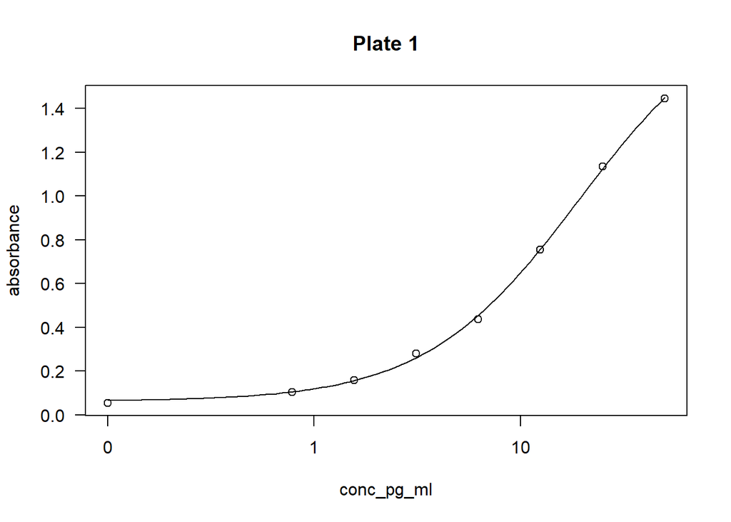

```r
plate_1_standard <- plate_1 |>
    left_join(standard)

model1<-drm(absorbance~conc_pg_ml,
             fct=LL.4(names=c("Slope", "Lower", "Upper", "ED50")),
data=plate_1_standard)
plot(model1,
     main = "Plate 1")
```

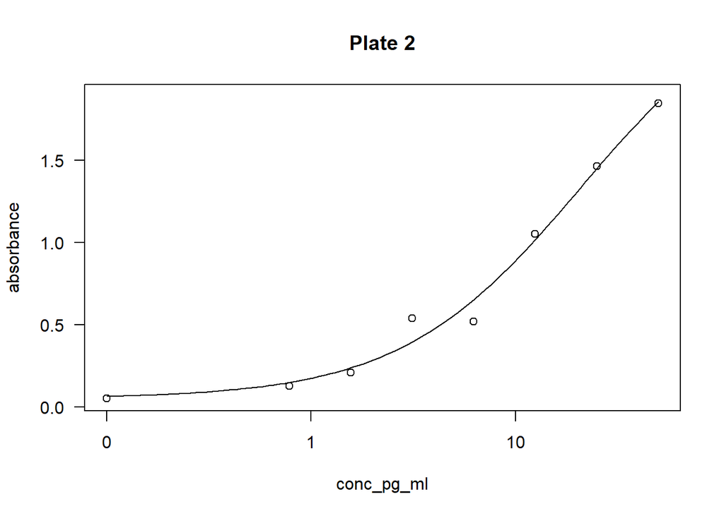

```r
plate_2_standard <- plate_2 |>
    left_join(standard)

model2<-drm(absorbance~conc_pg_ml,
             fct=LL.4(names=c("Slope", "Lower", "Upper", "ED50")),
data=plate_2_standard)
plot(model2,
     main = "Plate 2")
```

> For most ELISA, often linear regression does not work. An appropriate curve is usually a four parameter logistic regression.

## Estimate Concentration

```r
dilution_factor <- 800

plate_1_filter <- plate_1 |>
    filter(!grepl(pattern = "S", x = sample))

conc <-as.data.frame(ED(model1,plate_1_filter$absorbance,type="absolute",display=F))
conc_pg_ml <- conc$Estimate * 800

plate_1_filter <- cbind(plate_1_filter, conc_pg_ml)

###

plate_2_filter <- plate_2 |>
    filter(!grepl(pattern = "S", x = sample))

conc <-as.data.frame(ED(model1,plate_2_filter$absorbance,type="absolute",display=F))
conc_pg_ml <- conc$Estimate * 800

plate_2_filter <- cbind(plate_2_filter, conc_pg_ml)

plate_combined <- plate_1_filter |>
    bind_rows(plate_2_filter) |>
    mutate(conc_ng_ml = conc_pg_ml/1000) |>
    left_join(subject_characteristic) |>
    mutate(treatment = ifelse(treatment=="A", "fiber", "placebo"))

plate_summary <- plate_combined |>
    group_by(subject, treatment, timepoint) |>
    summarise(mean_conc_ng_ml = mean(conc_ng_ml),
              sd = sd(conc_ng_ml),
              cv = sd/mean_conc_ng_ml)

datatable(plate_summary)
```

|  | subject | treatment | timepoint | mean_conc_ng_ml | sd | cv |
| --- | --- | --- | --- | --- | --- | --- |
| 1 | 201 | fiber | post | 2.64443967495448 | 0.02580770926161 | 0.00975923538964989 |
| 2 | 201 | fiber | pre | 2.20404865935923 | 0.13558974800887 | 0.0615184911789967 |
| 3 | 201 | placebo | post | 1.33454478223395 | 0.101143632353784 | 0.0757888635138009 |
| 4 | 201 | placebo | pre | 1.86403731120855 | 0.311456178425618 | 0.167086879942164 |
| 5 | 202 | fiber | post | 4.85405635354941 | 0.194902527656293 | 0.0401525061639993 |
| 6 | 202 | fiber | pre | 7.19889570788717 | 0.344483004976775 | 0.0478522010812515 |
| 7 | 202 | placebo | post | 5.38659154580223 | 0.0606097424205399 | 0.0112519655342669 |
| 8 | 202 | placebo | pre | 6.90686395943362 | 0.921781969336989 | 0.133458828022519 |
| 9 | 203 | fiber | post | 1.8878333461409 | 0.294702502620109 | 0.15610620673829 |
| 10 | 203 | fiber | pre | 2.33002873900996 | 0.076550800296609 | 0.0328540154955925 |

[output cut: 70 more lines]

## Mixed Linear Model

```r
mix_model <- lmer(mean_conc_ng_ml ~ treatment*timepoint + (1|subject), data = plate_summary)

# Check the assumption: normality
shapiro.test(resid(mix_model))
```

```
##
##  Shapiro-Wilk normality test
##
## data:  resid(mix_model)
## W = 0.83705, p-value = 6.096e-08
```

```r
# ANOVA
summary(mix_model)
```

```
## Linear mixed model fit by REML. t-tests use Satterthwaite's method [
## lmerModLmerTest]
## Formula: mean_conc_ng_ml ~ treatment * timepoint + (1 | subject)
##    Data: plate_summary
##
## REML criterion at convergence: 437.8
##
## Scaled residuals:
##     Min      1Q  Median      3Q     Max
## -2.2571 -0.4543 -0.0950  0.3103  4.5694
##
## Random effects:
##  Groups   Name        Variance Std.Dev.
##  subject  (Intercept) 18.399   4.289
##  Residual              9.156   3.026
## Number of obs: 80, groups:  subject, 20
##
## Fixed effects:
##                               Estimate Std. Error      df t value Pr(>|t|)
## (Intercept)                     7.4053     1.1738 32.5130   6.309 4.16e-07 ***
## treatmentplacebo                0.4906     0.9569 57.0000   0.513   0.6101
## timepointpre                    1.8639     0.9569 57.0000   1.948   0.0564 .
## treatmentplacebo:timepointpre  -2.1257     1.3532 57.0000  -1.571   0.1218
## ---
## Signif. codes:  0 '***' 0.001 '**' 0.01 '*' 0.05 '.' 0.1 ' ' 1
##
## Correlation of Fixed Effects:
##             (Intr) trtmnt tmpntp
## tretmntplcb -0.408
## timepointpr -0.408  0.500
## trtmntplcb:  0.288 -0.707 -0.707
```

```r
anova(mix_model, ddf="K")
```

```
## Type III Analysis of Variance Table with Kenward-Roger's method
##                      Sum Sq Mean Sq NumDF DenDF F value Pr(>F)
## treatment            6.5492  6.5492     1    57  0.7153 0.4012
## timepoint           12.8357 12.8357     1    57  1.4019 0.2413
## treatment:timepoint 22.5920 22.5920     1    57  2.4674 0.1218
```

```r
# post hoc
emm <- emmeans(mix_model, specs = c("treatment", "timepoint"), lmer.df = "K")
con <- contrast(emm, interaction = "pairwise", lmer.df = "K")
con
```

```
##  treatment_pairwise timepoint_pairwise estimate   SE df t.ratio p.value
##  fiber - placebo    post - pre            -2.13 1.35 57  -1.571  0.1218
##
## Degrees-of-freedom method: kenward-roger
```

```r
summary_con <- summary(con)
p_value <- round(summary_con$p.value,3)
```

## Figure

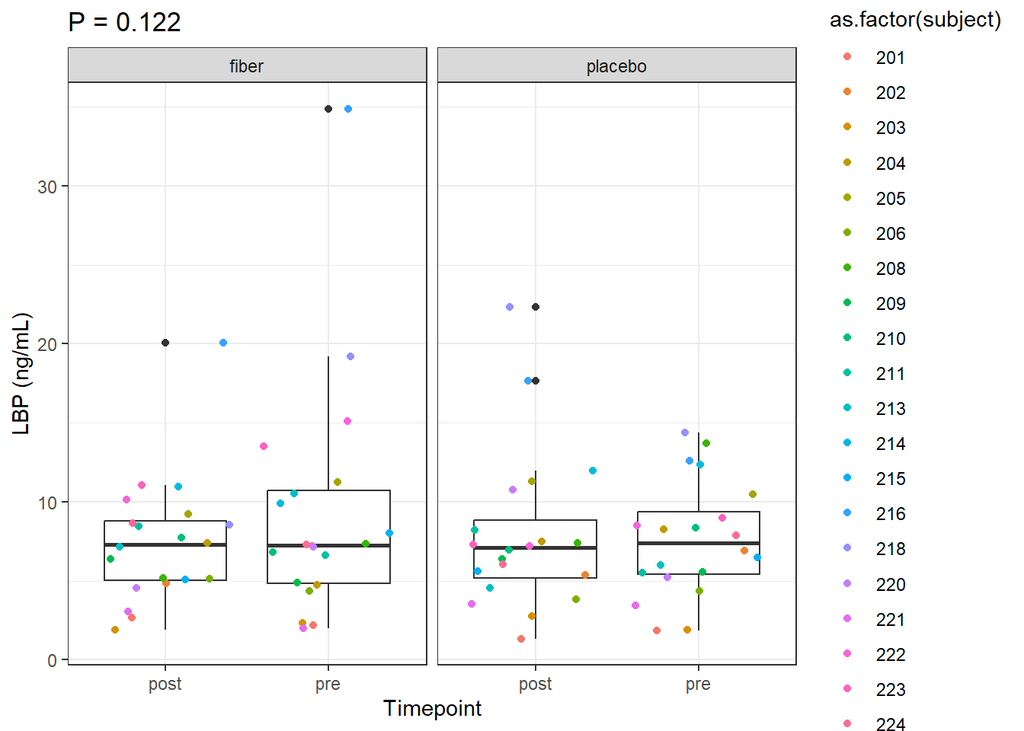

```r
# boxplot, all data points
ggplot(plate_summary, aes(timepoint, mean_conc_ng_ml))+
    geom_boxplot()+
    geom_point(aes(color = as.factor(subject)), position = position_jitter())+
    # geom_line(aes(color = subject, group = subject)) +
    facet_grid(~treatment) +
    theme_bw() +
        labs(y = "LBP (ng/mL)", x = "Timepoint", title = paste0("P = ",p_value))
```

## Correlation with LCAT

```r
lcat <- readRDS(here("LCAT","data","LCAT_summary_filter_223B.rds"))


lcat <- lcat |>
    dplyr::select(subject, treatment, timepoint, norm.LCAT.ratio)

lcat <- lcat |>
    left_join(plate_summary)

cor <- rmcorr(subject, measure1 = norm.LCAT.ratio, measure2 = mean_conc_ng_ml, dataset = lcat)
cor
```

```
##
## Repeated measures correlation
##
## r
## -0.01375141
##
## degrees of freedom
## 58
##
## p-value
## 0.9169455
##
## 95% confidence interval
## -0.2667447 0.2410149
```

> Repeated measure correlation shows that LCAT and LBP are not significantly correlated.

## LBP Rpeated Correlation with subject characteristics

```r
LBP <- plate_summary$mean_conc_ng_ml
# Extract the columns of interest
data_subset <- subject_characteristic[, 9:22]
# Assuming 'subject' is the name of your grouping variable
group_id <- subject_characteristic$subject

# Add the grouping variable and the repeated measures variable to the data subset
data_subset <- cbind(group_id = group_id, LBP = LBP, data_subset)



# List to store the results
results_list <- list()

# Loop to perform rmcorr for each variable
for(i in 3:(ncol(data_subset))) {
    results <- rmcorr(dataset = data_subset,
                      participant = "group_id",
                      measure1 = "LBP",
                      measure2 = names(data_subset)[i])
    results_list[[names(data_subset)[i]]] <- results
}

# Convert list to data frame
results_df <- results_list %>%
  purrr::map_dfr(function(x) {
    tibble(
      Rmcorr = x$r,
      CI_lower = x$CI[1],
      CI_upper = x$CI[2],
      p_value = x$p
    )
  }, .id = "Variable")

# Display as data table
datatable(results_df) |>
    formatRound(columns = 2:ncol(results_df), digits = 3)
```

|  | Variable | Rmcorr | CI_lower | CI_upper | p_value |
| --- | --- | --- | --- | --- | --- |
| 1 | age | -0.0426824809151967 | -0.29137146215315 | 0.211410569470701 | 0.743960449233291 |
| 2 | weight | 0.26941492550087 | 0.0188747286039746 | 0.488119551953752 | 0.0357586671724791 |
| 3 | height | 0.160619252068082 | -0.0950458302182871 | 0.39640643732435 | 0.216246315418903 |
| 4 | BMI | 0.165251427003311 | -0.0903282061616968 | 0.400409625371777 | 0.203115622743135 |
| 5 | Systolic BP | 0.0819527241800983 | -0.173447519896054 | 0.3270245286213 | 0.530077906535428 |
| 6 | Diastolic BP | 0.0164643528981946 | -0.236336251682729 | 0.267177357070064 | 0.899780264711696 |
| 7 | glucose | 0.134696210866708 | -0.121236795284194 | 0.37383667187935 | 0.300681557213836 |
| 8 | insulin | 0.0854072384834865 | -0.170071276853112 | 0.330127814935148 | 0.512822318829156 |
| 9 | Cholesterol | -0.207746344938094 | -0.436720140488717 | 0.0465074223299733 | 0.108149688075956 |
| 10 | HDL | -0.0641765446661603 | -0.310971675117091 | 0.190726522787562 | 0.623163068081954 |

[output cut: 4 more lines]

> Repeated measure correlation shows that weight is signficantly positively correlated with LBP concentration